# Predictions on Exercise Quality via Sensor Data

Nicholas Ng

Sunday, March 22, 2015

# Abstract

As part of the course project for the Practical Machine Learning course on Coursera, the Groupware@LES data on Weight Lifting Exercises was used to train a model for the purposes of predicting the quality of an exercise.

# Data Processing

To enable swift processing of all data, the following code attaches packages that enable multicore processing and explicitly requests for all processes to use the processor cluster for computations where possible.

```r
suppressMessages(library("cluster"))
suppressMessages(library("parallel"))
suppressMessages(library("doSNOW"))
coreNumber <- max(detectCores(),1)
cluster <- makeCluster(coreNumber, type = "SOCK",outfile="")
registerDoSNOW(cluster)
```

Additionally, to support the analysis to follow, the following packages are attached:

```r
suppressMessages(library("dplyr"))
suppressMessages(library("reshape2"))
suppressMessages(library("ggplot2"))
suppressMessages(library("caret"))
suppressMessages(library("randomForest"))
```

```r
urlTrain <- "https://d396qusza40orc.cloudfront.net/predmachlearn/pml-training.csv"
urlProb <- "https://d396qusza40orc.cloudfront.net/predmachlearn/pml-testing.csv"
dataTrain <- read.csv("./data/pml-training.csv", header = T,
                      stringsAsFactors = T)
dataProb <- read.csv("./data/pml-testing.csv", header = T,
                     stringsAsFactors = T)
```

For differentiation purposes, one has named the test dataset as “dataProb” and it will be referred to as “problem cases” for the remainder of this study due to the fact that the training data is partitioned into training/testing sets for cross-validation.

Once the data has been read into R, the training data set is partitioned:

```r
set.seed(1234)
inTrain <- createDataPartition(y = dataTrain$classe, p = 0.7, list = F)
training <- dataTrain[inTrain, ]
testing <- dataTrain[-inTrain, ]
```

A quick look at the head and summary of the dataset reveals that there are a number of columns which do not contain relevant or useful data:

```r
head(training)
summary(training)
```

The results have been printed in the appendix to prevent clutter. However as seen in Appendix A, the first 7 columns of the dataset do not contain any relevant data for analysis as they are simply identifiers for the individual data points. On the other hand, there are many other columns within the set which should contain data, but are either blank or appear to contain only “NA” values.

To validate that these variables are indeed not useful for analysis, the `nearZeroVar` function is used to identify variables which have near zero variance:

```r
nearZeroVar(training, saveMetrics = T)
```

Using a combination of information from the above methods (refer to Appendix A and B for the output), the relevant variables are then subsequently removed from both the training and testing partitions:

```r
trainClean <- select(training, -c(1:7, 12:36, 50:59, 69:83, 87:101,
                                  103:112, 125:139, 141:150))
testClean <- select(testing, -c(1:7, 12:36, 50:59, 69:83, 87:101,
                                103:112, 125:139, 141:150))
```

Of the remaining variables, a combined histogram plot is used to explore the data further, identifying if variable require normalisation or standardisation:

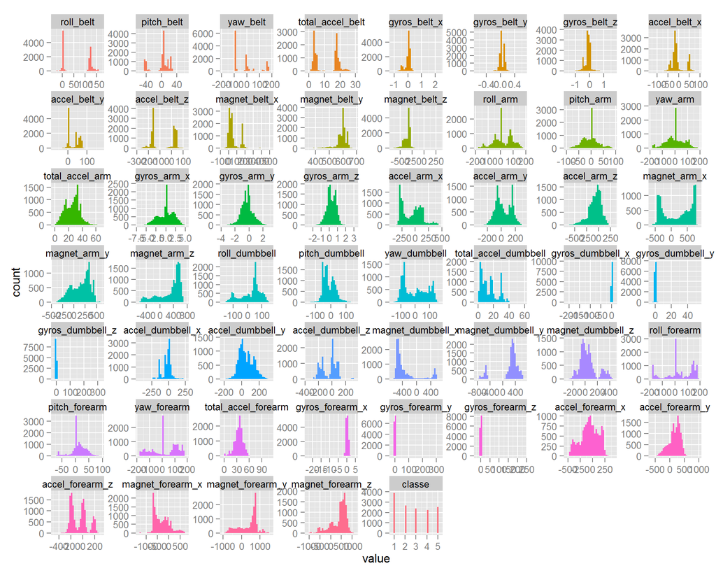

```r
trainLong <- trainClean
for (i in 1:length(trainLong)) {
    trainLong[, i] <- as.numeric(trainLong[, i])
    }
trainLong$id <- row.names(trainClean)
trainLong <- melt(trainLong, id.var="id")
g <- ggplot(trainLong, aes(x = value, fill = variable)) +
    facet_wrap( ~ variable, scale = "free") +
    geom_histogram() +
    theme(legend.position = "none")
suppressMessages(print(g))
```

Judging from the distributions of the variables, there are many variables which have a large absolute range, so it would be beneficial for one to normalise the variables:

```r
modNorm <- preProcess(trainClean[, -length(trainClean)],
                      method = c("scale", "center"))
trainNorm <- predict(modNorm, trainClean[, -length(trainClean)])
testNorm <- predict(modNorm, testClean[, -length(testClean)])
trainNorm$classe <- trainClean$classe
```

Lastly, although it is advisable to use Principal Component Analysis to reduce the number of dimensions given such a highly-dimensional dataset, doing so might reduce the accuracy of the model. Therefore, this was not done in this study.

# Model Building

Given that this is a classification-type problem, an appropriate prediction method was selected, which in this case, was the random forest model. The `randomForest` function from the package of the same name was used instead of using the `train` function from the `caret` package, due to computational efficiency:

```r
modfitRF <- randomForest(classe ~ ., data = trainNorm)
```

As seen earlier in the histogram plots, many variables were either very homogenous or clustered as specific values. Therefore, it is expected that the out-of-sample error would be very small, of about 1% or less. For confirmation of this figure, one can predict on the test set, and construct the confusion matrix, as follows:

```r
predRF <- predict(modfitRF, testNorm)
confusionMatrix(predRF, testing$classe)
```

```
## Confusion Matrix and Statistics
##
##           Reference
## Prediction    A    B    C    D    E
##          A 1674    6    0    0    0
##          B    0 1132    6    0    0
##          C    0    1 1020    5    1
##          D    0    0    0  958    1
##          E    0    0    0    1 1080
##
## Overall Statistics
##
##                Accuracy : 0.9964
##                  95% CI : (0.9946, 0.9978)
##     No Information Rate : 0.2845
##     P-Value [Acc > NIR] : < 2.2e-16
##
##                   Kappa : 0.9955
##  Mcnemar's Test P-Value : NA
##
## Statistics by Class:
##
##                      Class: A Class: B Class: C Class: D Class: E
## Sensitivity            1.0000   0.9939   0.9942   0.9938   0.9982
## Specificity            0.9986   0.9987   0.9986   0.9998   0.9998
## Pos Pred Value         0.9964   0.9947   0.9932   0.9990   0.9991
## Neg Pred Value         1.0000   0.9985   0.9988   0.9988   0.9996
## Prevalence             0.2845   0.1935   0.1743   0.1638   0.1839
## Detection Rate         0.2845   0.1924   0.1733   0.1628   0.1835
## Detection Prevalence   0.2855   0.1934   0.1745   0.1630   0.1837
## Balanced Accuracy      0.9993   0.9963   0.9964   0.9968   0.9990
```

Given the high accuracy of the model, the estimation of a less than 1% out-of-sample error rate is valid.

# Problem Case Prediction

Finally, to complete the analysis, the problem case data is processed and predicted in the same way as the previous datasets:

```r
probClean <- select(dataProb, -c(1:7, 12:36, 50:59, 69:83, 87:101,
                                 103:112, 125:139, 141:150, 160))
probNorm <- predict(modNorm, probClean)

probRF <- predict(modfitRF, probNorm)
probRF
```

```
##  1  2  3  4  5  6  7  8  9 10 11 12 13 14 15 16 17 18 19 20
##  B  A  B  A  A  E  D  B  A  A  B  C  B  A  E  E  A  B  B  B
## Levels: A B C D E
```

When submitted against the submission server, the above results yielded 100% correct answers.

# Appendix A - Head & Summary of Training Data Partition

```
##   X user_name raw_timestamp_part_1 raw_timestamp_part_2   cvtd_timestamp
## 2 2  carlitos           1323084231               808298 05/12/2011 11:23
## 3 3  carlitos           1323084231               820366 05/12/2011 11:23
## 4 4  carlitos           1323084232               120339 05/12/2011 11:23
## 5 5  carlitos           1323084232               196328 05/12/2011 11:23
## 6 6  carlitos           1323084232               304277 05/12/2011 11:23
## 7 7  carlitos           1323084232               368296 05/12/2011 11:23
##   new_window num_window roll_belt pitch_belt yaw_belt total_accel_belt
## 2         no         11      1.41       8.07    -94.4                3
## 3         no         11      1.42       8.07    -94.4                3
## 4         no         12      1.48       8.05    -94.4                3
## 5         no         12      1.48       8.07    -94.4                3
## 6         no         12      1.45       8.06    -94.4                3
## 7         no         12      1.42       8.09    -94.4                3
##   kurtosis_roll_belt kurtosis_picth_belt kurtosis_yaw_belt
```

[output cut: 265 more lines]

```
##        X            user_name    raw_timestamp_part_1 raw_timestamp_part_2
##  Min.   :    2   adelmo  :2729   Min.   :1.322e+09    Min.   :   294
##  1st Qu.: 4925   carlitos:2195   1st Qu.:1.323e+09    1st Qu.:252398
##  Median : 9814   charles :2468   Median :1.323e+09    Median :494703
##  Mean   : 9810   eurico  :2145   Mean   :1.323e+09    Mean   :500149
##  3rd Qu.:14694   jeremy  :2370   3rd Qu.:1.323e+09    3rd Qu.:750646
##  Max.   :19622   pedro   :1830   Max.   :1.323e+09    Max.   :998750
##
##           cvtd_timestamp new_window    num_window      roll_belt
##  28/11/2011 14:14:1060   no :13453   Min.   :  1.0   Min.   :-28.90
##  05/12/2011 11:24:1058   yes:  284   1st Qu.:221.0   1st Qu.:  1.10
##  30/11/2011 17:11:1015               Median :424.0   Median :113.00
##  05/12/2011 11:25:1001               Mean   :430.7   Mean   : 64.45
##  02/12/2011 14:57: 968               3rd Qu.:644.0   3rd Qu.:123.00
##  02/12/2011 13:34: 965               Max.   :864.0   Max.   :162.00
##  (Other)         :7670
##    pitch_belt          yaw_belt       total_accel_belt kurtosis_roll_belt
##  Min.   :-54.9000   Min.   :-179.00   Min.   : 0.00             :13453
##  1st Qu.:  1.7500   1st Qu.: -88.30   1st Qu.: 3.00    #DIV/0!  :    9
##  Median :  5.2800   Median : -13.00   Median :17.00    -1.908453:    2
##  Mean   :  0.2866   Mean   : -10.95   Mean   :11.32    -0.021024:    1
##  3rd Qu.: 15.2000   3rd Qu.:  14.00   3rd Qu.:18.00    -0.025513:    1
##  Max.   : 60.3000   Max.   : 179.00   Max.   :29.00    -0.033935:    1
##                                                        (Other)  :  270
##  kurtosis_picth_belt kurtosis_yaw_belt skewness_roll_belt
##           :13453            :13453              :13453
##  #DIV/0!  :   23     #DIV/0!:  284     #DIV/0!  :    8
##  -0.150950:    3                       0.000000 :    3
##  7.770402 :    3                       0.422463 :    2
##  -0.684748:    2                       -0.003095:    1
##  -0.686349:    2                       -0.014020:    1
##  (Other)  :  251                       (Other)  :  269
##  skewness_roll_belt.1 skewness_yaw_belt max_roll_belt     max_picth_belt
##           :13453             :13453     Min.   :-94.300   Min.   : 3.00
##  #DIV/0!  :   23      #DIV/0!:  284     1st Qu.:-88.000   1st Qu.: 5.00
##  0.000000 :    4                        Median : -5.100   Median :18.00
##  -3.072669:    3                        Mean   : -5.107   Mean   :13.01
##  -0.587156:    2                        3rd Qu.: 20.025   3rd Qu.:19.00
##  -0.733570:    2                        Max.   :177.000   Max.   :30.00
##  (Other)  :  250                        NA's   :13453     NA's   :13453
```

[output cut: 305 more lines]

```
##  Min.   : -8.0900   Min.   :-498.00   Min.   :-595.0   Min.   :-446.00
##  1st Qu.: -0.1800   1st Qu.:-176.00   1st Qu.:  57.0   1st Qu.:-182.00
##  Median :  0.0800   Median : -57.00   Median : 201.0   Median : -40.00
##  Mean   :  0.1575   Mean   : -61.14   Mean   : 163.7   Mean   : -55.51
##  3rd Qu.:  0.4900   3rd Qu.:  77.00   3rd Qu.: 313.0   3rd Qu.:  26.00
##  Max.   :231.0000   Max.   : 389.00   Max.   : 923.0   Max.   : 291.00
##
##  magnet_forearm_x  magnet_forearm_y magnet_forearm_z classe
##  Min.   :-1280.0   Min.   :-896.0   Min.   :-966.0   A:3906
##  1st Qu.: -615.0   1st Qu.:  -3.0   1st Qu.: 186.0   B:2658
##  Median : -376.0   Median : 590.0   Median : 509.0   C:2396
##  Mean   : -311.2   Mean   : 378.9   Mean   : 391.6   D:2252
##  3rd Qu.:  -73.0   3rd Qu.: 736.0   3rd Qu.: 652.0   E:2525
##  Max.   :  672.0   Max.   :1480.0   Max.   :1090.0
##
```

# Appendix B - Near Zero Variance Analysis Table

```
##                            freqRatio percentUnique zeroVar   nzv
## X                           1.000000  100.00000000   FALSE FALSE
## user_name                   1.105754    0.04367766   FALSE FALSE
## raw_timestamp_part_1        1.000000    6.09303341   FALSE FALSE
## raw_timestamp_part_2        1.250000   89.25529592   FALSE FALSE
## cvtd_timestamp              1.001890    0.14559220   FALSE FALSE
## new_window                 47.369718    0.01455922   FALSE  TRUE
## num_window                  1.000000    6.23134600   FALSE FALSE
## roll_belt                   1.098413    8.07308728   FALSE FALSE
## pitch_belt                  1.106870   12.22974449   FALSE FALSE
## yaw_belt                    1.060345   12.93586664   FALSE FALSE
## total_accel_belt            1.062500    0.21110868   FALSE FALSE
## kurtosis_roll_belt       1494.777778    2.00917231   FALSE  TRUE
## kurtosis_picth_belt       584.913043    1.69614909   FALSE  TRUE
## kurtosis_yaw_belt          47.369718    0.01455922   FALSE  TRUE
## skewness_roll_belt       1681.625000    2.00189270   FALSE  TRUE
## skewness_roll_belt.1      584.913043    1.78350440   FALSE  TRUE
## skewness_yaw_belt          47.369718    0.01455922   FALSE  TRUE
## max_roll_belt               1.000000    1.13561913   FALSE FALSE
## max_picth_belt              1.756098    0.14559220   FALSE FALSE
## max_yaw_belt              611.500000    0.42949698   FALSE  TRUE
## min_roll_belt               1.100000    1.10650069   FALSE FALSE
## min_pitch_belt              2.050000    0.10919415   FALSE FALSE
## min_yaw_belt              611.500000    0.42949698   FALSE  TRUE
## amplitude_roll_belt         1.083333    0.81531630   FALSE FALSE
## amplitude_pitch_belt        3.255319    0.08007571   FALSE FALSE
## amplitude_yaw_belt         50.766038    0.02911844   FALSE  TRUE
## var_total_accel_belt        1.596154    0.37853971   FALSE FALSE
## avg_roll_belt               1.100000    1.07738225   FALSE FALSE
## stddev_roll_belt            1.117647    0.40765815   FALSE FALSE
## var_roll_belt               1.648148    0.52413191   FALSE FALSE
## avg_pitch_belt              1.333333    1.27393172   FALSE FALSE
## stddev_pitch_belt           1.410256    0.29118439   FALSE FALSE
## var_pitch_belt              1.482759    0.39309893   FALSE FALSE
## avg_yaw_belt                1.142857    1.41224430   FALSE FALSE
## stddev_yaw_belt             1.512821    0.36398049   FALSE FALSE
## var_yaw_belt                1.448276    0.80803669   FALSE FALSE
## gyros_belt_x                1.083244    0.96090850   FALSE FALSE
## gyros_belt_y                1.135154    0.48773386   FALSE FALSE
## gyros_belt_z                1.047733    1.20841523   FALSE FALSE
```

[output cut: 106 more lines]

```
## stddev_pitch_forearm       29.500000    1.63791221   FALSE  TRUE
## var_pitch_forearm          59.000000    1.64519182   FALSE  TRUE
## avg_yaw_forearm            59.000000    1.64519182   FALSE  TRUE
## stddev_yaw_forearm         61.000000    1.63063260   FALSE  TRUE
## var_yaw_forearm            61.000000    1.63063260   FALSE  TRUE
## gyros_forearm_x             1.056000    2.08196841   FALSE FALSE
## gyros_forearm_y             1.022305    5.25587828   FALSE FALSE
## gyros_forearm_z             1.140351    2.11836646   FALSE FALSE
## accel_forearm_x             1.109375    5.64897721   FALSE FALSE
## accel_forearm_y             1.090909    7.13401762   FALSE FALSE
## accel_forearm_z             1.112150    4.05474267   FALSE FALSE
## magnet_forearm_x            1.087719   10.68646721   FALSE FALSE
## magnet_forearm_y            1.103448   13.32168596   FALSE FALSE
## magnet_forearm_z            1.069767   11.72745141   FALSE FALSE
## classe                      1.469526    0.03639805   FALSE FALSE
```